# Lab 9 - Interactions and the Generalized Linear Model with solutions

Univariate Statistics with R

Today’s lab is primarily focused on extending our knowledge/experience of conducting and interpreting linear models.

## Interactions in linear models

### Specifying interactions in R

In the lecture last week, you were introduced to interactions in linear models. Therefore we need to know how to tell R to also fit interaction terms in our calls to `lm()`.

```r
lm(y ~ x1)
lm(y ~ x1 + x2)
```

So far, these are the types of linear models we have been asking R to fit. In the first example, the command tells R we want to predict `y` using the explanatory variable `x1`. The second example extends this by also using `x2` as an explanatory variable. To also ask for R to fit the interaction between `x1` and `x2`, we can execute:

```r
lm(y ~ x1 + x2 + x1:x2)
```

We use a colon to separate two terms to indicate we want to fit the interaction between these terms. An alternative method is:

```r
lm(y ~ x1 * x2)
```

Using the * tells R to fit the full model using these variables: each of the variables individually and the interaction term.

### Simulating data

Today’s exercise is a little different: We’re going to analyse a dataset, but we’re going to build it ourselves.  
The purpose if this is because we can define the relationships between the variables, and so link this more clearly to our regression formula ($y_i=b_0+b_1x_{1i}+b_2x_{2i}+{}...{}+b_nx_{ni}+\epsilon_i$) and model output.

**Task 1:** Create a data frame to hold your data with participant labels for 100 people. To do this, you can simple use the colon `:` to make a sequence from 1 to 100, and wrap the whole thing in `factor()` to make sure R knows that it is not numeric.

```r
my.data <- data.frame(ppt = factor(1:100))
```

**Task 2:** Now let’s add in some information about these participants. Give some values for their `age`, and their `musicality` (some measure of how interested the participant is in music generally).

You shouldn’t need much guidance here, except to make up some values that vary plausibly for each column. So, for example, if you thought that `age` was best expressed in years and our participants’ ages should vary uniformly from 20 to 60, you might type:

```r
my.data$age <- runif(100, 20, 60)
```

*but this is only an example.* You might assume that the age of participants is normally distributed; you might want to express it in months; and so on.

Similarly, you can define `musicality` however you like: You could use `rnorm()` or some other random function to assign values to it; or you might want to `sample()` (with replacement) from a strict set of numbers such as `1:7`, for example.

```r
## Here are some simple versions based on the hints above:
my.data$musicality <- sample(c(1:7), 100, replace = TRUE)
```

**Task 3:** Have a look at the dataset you have created: `my.data`. Have a look at a summary of the variables you have created: `summary(my.data)`. Do they look sensible? *Most likely yes, but make sure nothing stands out as strange.*

```r
## here's the summary based on the commands above:
summary(my.data)
      ppt          age          musicality
 1      : 1   Min.   :20.10   Min.   :1.00
 2      : 1   1st Qu.:31.52   1st Qu.:2.00
 3      : 1   Median :39.64   Median :4.00
 4      : 1   Mean   :40.38   Mean   :4.05
 5      : 1   3rd Qu.:51.35   3rd Qu.:6.00
 6      : 1   Max.   :59.63   Max.   :7.00
 (Other):94
```

**Task 4:** OK, now we want to create a variable called `spotify_hours` in our data frame, for the number of hours spent listening to spotify over the course of a year. We want this to be a *function* of `musicality` and `age`. In other words, you’re being asked: `What is the (fictional) way in which age and musicality predict the numbers of hours that people listen to spotify over the course of a year?’ To do this, you’ll need to think about regression equations in general, and in particular, about interaction terms. How do age and musicality *interact*? Will old musical people listen to spotify less than young musical people? And so on. The exact formula is *up to you* but, it’s a linear equation, so it should be something like:

```r
my.data$spotify_hours <- ... + (... * my.data$age) + (... * my.data$musicality) +
  (... * my.data$age * my.data$musicality)
```

```r
# could be anything really, but how about:
my.data$spotify_hours <- 500 - 5 * my.data$age +
  2 * my.data$musicality +
  1 * my.data$age * my.data$musicality
```

In this equation, the …’s represent spaces where $b_0$, $b_1$, $b_2$, and so on *(see slides 36-37 from lecture 8)*. Which means that what this equation is actually calculating is $\widehat{\text{spotify_hours}}$, the *estimated* (or fitted) value of `spotify_hours` *(based on your choices of $b_0$, $b_1$, etc.)*. Your job is to chose $b$s that give a plausible estimate, for whatever you think the relationship might be.

### Visualising

**Task 5:** Have a look at your data. There are various ways of doing this! For a fancy 3D-plot you can install the `plotly` package and try the code below[^1], and then move the resulting graph around with your mouse.

```r
library(plotly)
# if you don't include the '~'s, the axes will be labelled 'X', 'y', and 'z'.
with(my.data, plot_ly(x = ~age, y = ~musicality, z = ~spotify_hours))
```

If you are having problems with `plotly` or want to stay within 2-dimensions, try a flat plot, like this:

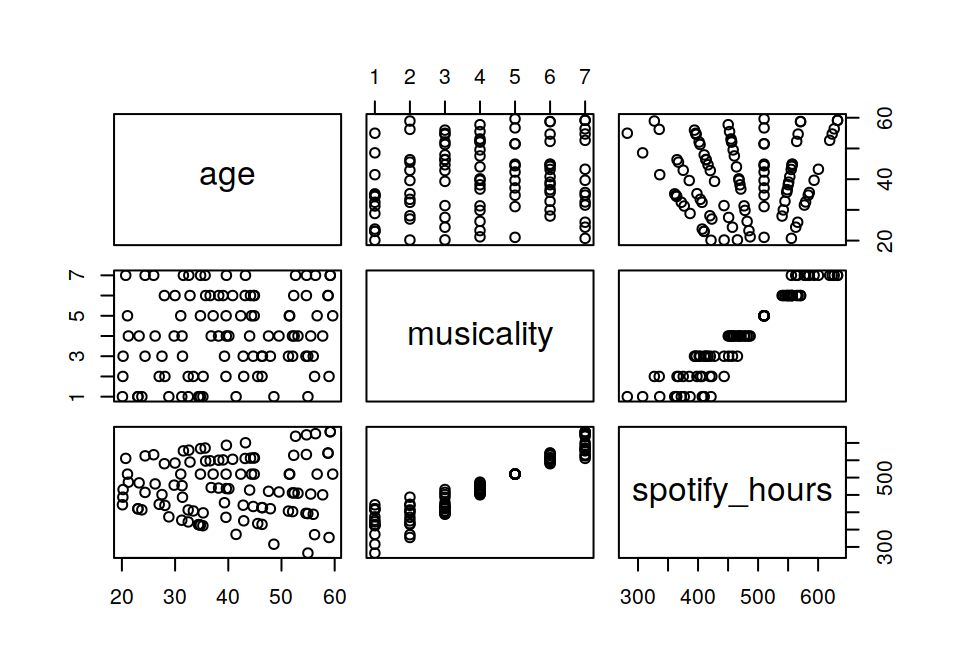

```r
plot(my.data[, c('age', 'musicality', 'spotify_hours')])
```

**Task 6:** Does everything look relatively plausible? If not, you could start again at Task 4 (or earlier), changing values or the formula to create `spotify_hours` until you’re happy with the result.

**Task 7:** The `spotify_hours` data you’ve created above is of *fitted values*, but real data is *noisy* - even when the relationship is extremely strong the real values will not lie perfectly on the ‘line of best fit’. So, add some noise to `spotify_hours`! Remember that the noise will have to be normally distributed to match the assumptions of a linear model. Refer back to the formalisations of the linear models in the lecture slides. The noise you are adding corresponds to the error term in the model formalisation - **$\epsilon_i$**. You might want to experiment with the size (sd) of the noise a little…

*Tip:* R makes it really easy to add a value to every element of a vector. To add 5 to every element of vector `x` you can execute `x + 5`. Combine this with the fact that the noise you are adding needs to be normally distributed.

```r
# it should be fairly easy to do this, although obviously the sd of the noise depends on
# the scale of the outcome variable
my.data$spotify_hours <- my.data$spotify_hours + rnorm(100, 0, 5)
```

### Modelling

**Task 8:** Run a linear regression to test how `age`, `musicality`, and their interaction predict `spotify_hours`. Examine your model. How close are the coefficients to the $b$ values that you initially entered into the equation?

```r
model <- lm(spotify_hours ~ age * musicality, data = my.data)
summary(model)

Call:
lm(formula = spotify_hours ~ age * musicality, data = my.data)

Residuals:
     Min       1Q   Median       3Q      Max
-13.2675  -2.6675   0.0486   3.3813  13.3833

Coefficients:
                Estimate Std. Error t value Pr(>|t|)
(Intercept)    501.20103    3.86983 129.515   <2e-16 ***
age             -5.06902    0.09968 -50.855   <2e-16 ***
musicality       1.87956    0.87536   2.147   0.0343 *
age:musicality   1.00817    0.02181  46.231   <2e-16 ***
---
Signif. codes:  0 '***' 0.001 '**' 0.01 '*' 0.05 '.' 0.1 ' ' 1

Residual standard error: 4.937 on 96 degrees of freedom
Multiple R-squared:  0.9965,    Adjusted R-squared:  0.9964
F-statistic:  9241 on 3 and 96 DF,  p-value: < 2.2e-16
```

**Task 9:** Check the model assumptions. Are the residuals normal? Do the other diagnostics look sensible?

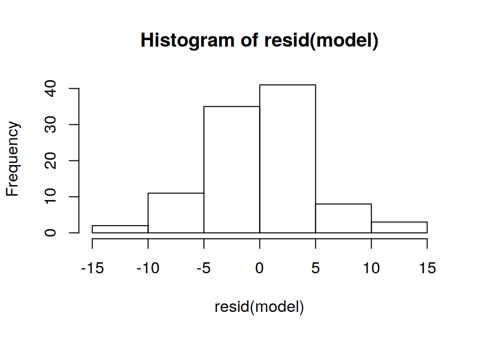

```r
hist(resid(model))
```

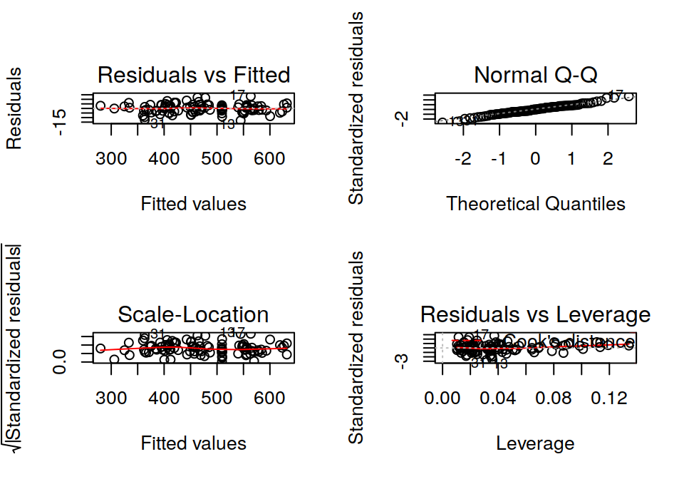

```r
par(mfrow = c(2, 2)) # to plot all of the below in one window
plot(model)
```

```r
par(mfrow = c(1, 1)) # revert back to one plot per window
```

**Task 10:** Re-run the equation you created at Task 4 (this resets the `spotify_hours` variable to the exact fitted values without the noise ($\epsilon$)). Now add a different type of residual that isn’t sampled from the normal distribution like before – use a different `r-` (*i.e.,* not `rnorm`) function, or generate the residuals in some different way. Re-run the regression and check the model assumptions. What has changed?

*Tip:* Before, we added noise to `spotify_hours` by randomly selecting values using `rnorm()` which should have ensured the added noise was more-or-less normally distributed. Here, we want to make sure the added noise is **not** normally distributed. Think about the continuous probability distributions you have come across in lectures and/or the Navarro textbook that are not normal. One of many possibilities might be the chi-square distribution with low degrees of freedom.

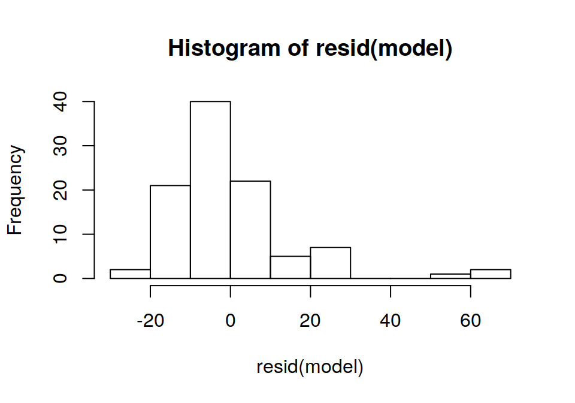

```r
## obviously you could choose almost anything here
my.data$spotify_hours <- my.data$spotify_hours + 10*rchisq(100, 1)
model <- lm(spotify_hours ~ age * musicality, data = my.data)
summary(model)

Call:
lm(formula = spotify_hours ~ age * musicality, data = my.data)

Residuals:
    Min      1Q  Median      3Q     Max
-22.327  -9.482  -3.450   3.482  69.918

Coefficients:
                Estimate Std. Error t value Pr(>|t|)
(Intercept)    497.21243   12.27265  40.514   <2e-16 ***
age             -4.61815    0.31611 -14.609   <2e-16 ***
musicality       4.55700    2.77610   1.642    0.104
age:musicality   0.91980    0.06916  13.300   <2e-16 ***
---
Signif. codes:  0 '***' 0.001 '**' 0.01 '*' 0.05 '.' 0.1 ' ' 1

Residual standard error: 15.66 on 96 degrees of freedom
Multiple R-squared:  0.9648,    Adjusted R-squared:  0.9637
F-statistic: 878.3 on 3 and 96 DF,  p-value: < 2.2e-16
hist(resid(model))
```

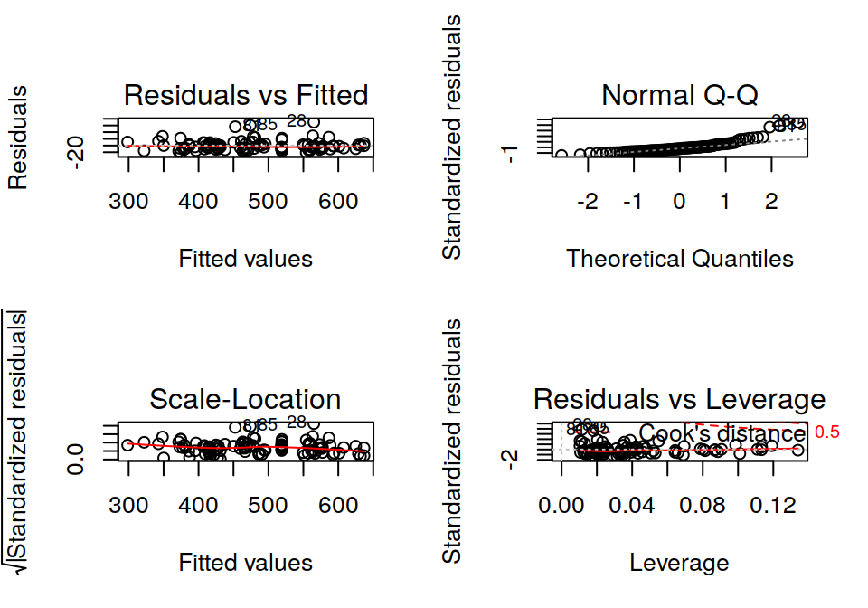

```r
par(mfrow = c(2, 2))
plot(model)
```

```r
par(mfrow = c(1, 1))
### etc.
```

If you selected a continuous measure of musicality you were working with a *continuous*$\times$*continuous* interaction. A good way to visualise this is to ‘bin’ the data based on one of the explanatory variables. In the example above we might create a grouped age variable that split age into 4 or 5 equal sized categories (the function `cut()` will help you to achieve this). Then create plots of `spotify_hours` by `musicality` for each of these groups separately (or you could put them in one plot and use a method to identify which points belong to which group, it’s up to you). A significant interaction in our models suggests that the pattern across each group should not be identical, there should be some deviation.

**Task 11:** *If you have time*: Create these plots for your data to visualise any interaction.

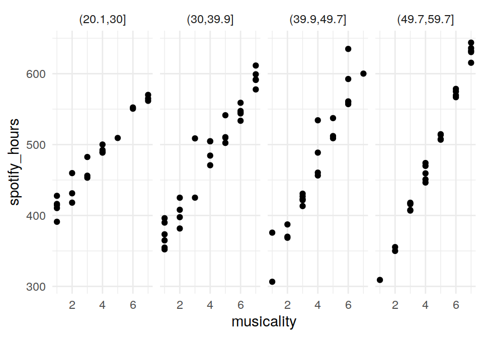

```r
# A few different examples of illustrating this:

my.data$cutAge <- cut(my.data$age, 4)

#a ggplot
library(ggplot2)
ggplot(data = my.data, aes(x = musicality, y = spotify_hours)) +
  geom_point()+
  theme_minimal()+
  facet_grid(~cutAge)
```

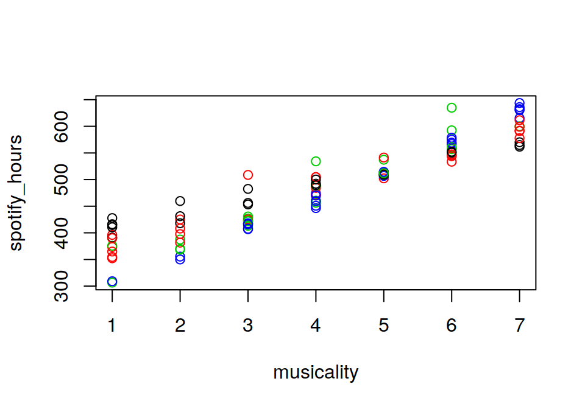

```r
#plot() colouring by age bin
with(my.data, plot(musicality, spotify_hours, col = cutAge))
```

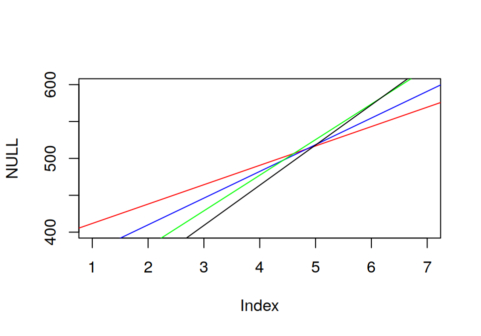

```r
#alternatively, plot each fitted line using abline()
#Note: repeat command, changing the subset variable and col on each
plot(NULL, xlim = c(1, 7), ylim = c(400, 600))
abline(lm(spotify_hours ~ musicality,
          data = subset(my.data, cutAge == levels(cutAge)[1])), col = "red")
abline(lm(spotify_hours ~ musicality,
          data = subset(my.data, cutAge == levels(cutAge)[2])), col = "blue")
abline(lm(spotify_hours ~ musicality,
          data = subset(my.data, cutAge == levels(cutAge)[3])), col = "green")
abline(lm(spotify_hours ~ musicality,
          data = subset(my.data, cutAge == levels(cutAge)[4])), col = "black")
```

## General**ised** Linear Model

We’re now going to take a look at the *generalised linear model*, which you were introduced to in this weeks lecture (lecture 9).

In the lecture, we saw how to model the odds that an alien would be splatted by a disco ball given their quality of singing. Along similar lines, we’re now going to construct a model of the odds of someone surviving the sinking of the titanic, given factors such as age, gender, class of ticket etc.

**Task 12:** Download the `titanic.csv` dataset from learn and read it in.

```r
titanic<-read.csv("titanic.csv")
titanic<-na.omit(titanic)
titanic <- janitor::clean_names(titanic)
```

**Task 13:** Plot the `survived` variable against the `pclass` variable, and use `abline()` to add to this the line for `lm(survived ~ pclass, data = titanic)`.

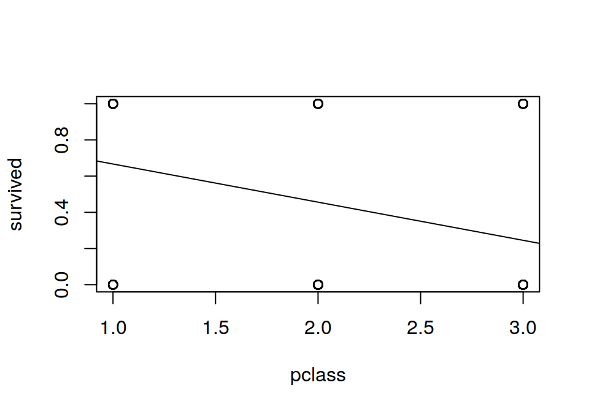

```r
with(titanic, plot(survived ~ pclass))
abline(lm(survived~pclass, data=titanic))
```

But remember that probability **can’t** be linear.  
Odds, ranging from 0 to Infinity, are calculated as $p(x)/(1-p(x))$.

**Task 14:** If the probability of someone surviving is 0.6. What are the odds, and what are the log odds?

```r
(0.6/(1-0.6)) # odds
[1] 1.5
log(0.6/(1-0.6)) # log odds
[1] 0.4054651
```

**Task 15:** Use `glm()` to model `survival` predicted by `pclass`. Remember to set `family=binomial`, and take a look at the coefficients using `coef()`.

```r
logit_mod <- glm(survived ~ pclass, data = titanic, family=binomial)

coef(logit_mod)
(Intercept)      pclass
  1.6205282  -0.9119899
```

Where the equation for our linear model was $y=b_0+b_1x$, for our logit model it is $ln(\frac{p}{(1-p)})=b_0+b_1x$.  
For the model we just ran, it is $ln(\frac{p}{(1-p)})=1.62-0.91*pclass$. So we can construct these fitted values using the code below:

```r
titanic$fit = 1.6205282 - 0.9119899*titanic$pclass
#or
titanic$fit = coef(logit_mod)[1] + coef(logit_mod)[2]*titanic$pclass
```

We can, from these numbers, get out the predicted probability of survival using the inverse logit $p=\frac{e^L}{(1+e^L)}$ (this is the inverse of the log odds formula).

```r
predicted_probs <- exp(titanic$fit) / (1 + exp(titanic$fit))
```

And this is exactly what we get when we use the predict() function!  
**Note:** we specify `type="response"` here, but if you use `type="link"` you get the log odds we just calculated.

```r
titanic$p_surv <- predict(logit_mod, type="response")

#and check that they are the same using the all.equal() function
all.equal(predicted_probs, titanic$p_surv)
[1] TRUE
```

**Maximum likelihood estimation** How does the model find the coefficients? We’re no longer talking about minimising sums of squares, like we were with a continuous variable and `lm()`. This is also why we don’t have things like $R^2$ for logit regression, because $SS_\text{regression}/SS_\text{total}$ no longer makes sense in the context of 0s and 1s.

Instead, models are fitted use Maximum Likelihood Estimation (MLE) to work out the coefficients which maximise the likelihood of the observed data. (There’s a lot of info on MLE if you want to google it!)

**Task 16:** Now that we have our fitted values in the `p_surv` variable, we can compare those to the observed data.

**Task 16.1:** Use the `ifelse()` function to assign values of 0 and 1 to the `p_surv` predictions.

```r
titanic$p_surv <- ifelse(titanic$p_surv > 0.5, 1, 0)
```

**Task 16.2:** Create a table of `p_surv` against `survived`.

```r
table(
  actual = titanic$survived,
  predicted = titanic$p_surv
)
      predicted
actual   0   1
     0 360  64
     1 168 122
```

[^1]: If the plot disappears after a split-second, just click inside the RStudio plotting window and it should pop back up.